# Gaia Field Stars (CMD)

```python
import matplotlib.pyplot as plt
import numpy as np

from astropy.table import QTable, vstack
from astropy import units as u

from matplotlib.patches import Rectangle, Circle, Ellipse, Polygon

from astroquery.gaia import Gaia
```

# Instructions

### Enter the coordinates of the center of your field (`l`, `b`).

- Use a galactic longitude (`l`) of somewhere between 10 and 90 degrees
- Use a galactic latitude (`b`) of somewhere between +35 and +45 degrees

```python
my_object_l = 20
my_object_b = 40
```

## Get the the Gaia data for your field

Create and run a Gaia query to find a **high quality complete representitive sample** of 5,000 +/- 200 objects that are brighter than 17th magnutude, have a parallax SNR > 15, and have the bp-rp colors.

Adjust the radius of your search circular search window and make sure you are not cutting off any objects. See the `Note on SELECT-ORDER Bias issues` section from the HQ_Gaia notebook.

You will want the columns: `source_id, l, b, phot_g_mean_mag, bp_rp, parallax, parallax_over_error`

**Don't print out the entire object table!**

```python
my_query = f"""
SELECT TOP 5500
source_id, l, b, phot_g_mean_mag, bp_rp, parallax, parallax_over_error
FROM gaiadr3.gaia_source_lite
WHERE DISTANCE( POINT({my_object_l}, {my_object_b}), POINT(l, b) ) < 1.47
AND phot_g_mean_mag  < 17
AND parallax_over_error > 15
AND bp_rp IS NOT NULL
ORDER BY parallax DESC
"""
```

```python
my_job_query = Gaia.launch_job_async(my_query)
```

```
INFO: Query finished. [astroquery.utils.tap.core]
```

```python
print(my_job_query)
```

```
<Table length=4909>
        name         dtype  unit                            description
------------------- ------- ---- ------------------------------------------------------------------
          source_id   int64      Unique source identifier (unique within a particular Data Release)
                  l float64  deg                                                 Galactic longitude
                  b float64  deg                                                  Galactic latitude
    phot_g_mean_mag float32  mag                                              G-band mean magnitude
              bp_rp float32  mag                                                     BP - RP colour
           parallax float64  mas                                                           Parallax
parallax_over_error float32                                  Parallax divided by its standard error
Jobid: 204d5395-0218-11f1-b809-bc97e148b76b-O
Phase: COMPLETED
Owner: None
Output file: async_20260204222327.vot
Results: None
```

```python
my_table = my_job_query.get_results()
my_table[0:2]
```

*Table length=2*

| source_id int64 | l deg float64 | b deg float64 | phot_g_mean_mag mag float32 | bp_rp mag float32 | parallax mas float64 | parallax_over_error float32 |
| --- | --- | --- | --- | --- | --- | --- |
| 4453239765733463936 | 21.77949582332958 | 40.160140232640344 | 10.659685 | 2.4957838 | 73.71779207255106 | 2986.8154 |
| 4450442260257203328 | 19.515971466722686 | 38.58925753260391 | 12.521749 | 2.6067924 | 36.383852518452024 | 1596.7264 |

### How many objects did your query return?

```python
np.size(my_table)
```

```
4909
```

### Use `parallax` and `phot_g_mean_mag` to get **distance** (in pc) and the **absolute magnitude** ($G_{M}$)

- Add them as columns to the data table

```python
my_table['distance'] = my_table['parallax'].to(u.parsec, equivalencies=u.parallax())
```

```python
def find_absmag(my_gmag, my_distance):
    result = my_gmag - 5 * np.log10( my_distance / (10 * u.parsec)) * u.mag
    return result

my_table['abs_g'] = find_absmag(my_gmag = my_table['phot_g_mean_mag'],
                                 my_distance = my_table['distance']
                               ) * u.mag
```

```python
my_table[0:2]
```

*Table length=2*

| source_id int64 | l deg float64 | b deg float64 | phot_g_mean_mag mag float32 | bp_rp mag float32 | parallax mas float64 | parallax_over_error float32 | distance pc float64 | abs_g mag float64 |
| --- | --- | --- | --- | --- | --- | --- | --- | --- |
| 4453239765733463936 | 21.77949582332958 | 40.160140232640344 | 10.659685 | 2.4957838 | 73.71779207255106 | 2986.8154 | 13.565246216487695 | 9.997546730654124 |
| 4450442260257203328 | 19.515971466722686 | 38.58925753260391 | 12.521749 | 2.6067924 | 36.383852518452024 | 1596.7264 | 27.48472002773349 | 10.326291955802041 |

## Make a subset of all of the *white dwarf* stars in your field

- You will need information from the CMD on the back your Gaia Info Sheet.
- You will need to make a cut based on the color (`bp_rp`) and Absolute magnitude (G$_M$).
- It may be easier to make a few smaller tables and combine them.

```python
my_dwarf_table1 = my_table[(my_table['bp_rp'] > 1) &
    (my_table['bp_rp'] < 2) &
    (my_table['abs_g'] > 13)]
my_dwarf_table2 = my_table[(my_table['bp_rp'] < 1) &
    (my_table['abs_g'] > 12) ]
my_dwarf_table3 = my_table[(my_table['bp_rp'] < 0.7) &
    (my_table['abs_g'] < 12) &
                            (my_table['abs_g'] > 8)]
```

```python
my_dwarf_table = vstack(
    [my_dwarf_table1, my_dwarf_table2, my_dwarf_table3]
)
```

### How many of your objects are white dwarf stars?

```python
np.size(my_dwarf_table)
```

```
3
```

## Make a subset of the 300 nearest stars

```python
my_table.sort('distance')
my_near300=my_table[:300]
```

## Make a subset of the 300 most distant stars

```python
my_table.sort('distance')
my_distant300=my_table[-300:]
```

# Create the following plot

- All on one page using `.subplot_mosaic`
- Total size 12 inches wide, 15 inches high
- With the following relative proportions:

```
          --------------------
          |                  |
          |                  |
          |                  |
          |                  |
          |      Plot A      |
          |                  |
          |                  |
          |                  |
          |                  |
          --------------------
          |                  |
          |     Plot B       |
          --------------------
```

## Plot A - An annotated color magnitude diagram (`bp_rp` vs. $G_{M}$) of your field.

- Both axes labeled
- A title for the figure
- Plot all of the stars
- A symbol and label placed at the position of the Sun (**bp_rp** = 0.82, $G_{M}$ = 4.67)
- White dwarf stars plotted with a different symbol, color, and size
- 300 nearest stars plotted with a different symbol, color, and size
- 300 most distant stars plotted with a different symbol, color, and size
- **Use annotations (arrows, shapes, text) to make everything clear**

## Plot B - A histrogram of the `bp_rp` colors of the stars in your field.

- Three histograms on the same plot
  - Set the Y-axis to `log`
  - Use a bin size of 0.1 mag
  - A histogram of **ALL** of the stars in the field
  - A histogram of the 300 nearest stars in the field (in a different color)
  - A histogram of the 300 most distant stars in the field (in a different color)
- All three histograms should be clearly labeled and easy to distinguish
- Both axes labeled

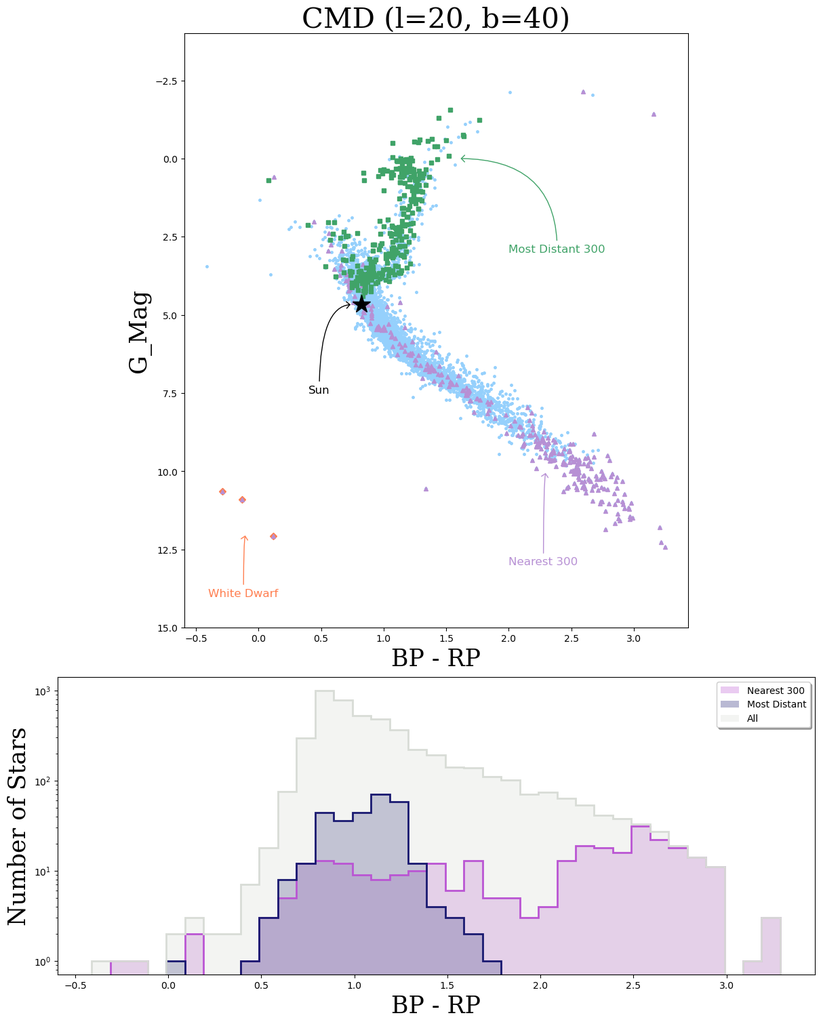

```python
fig, ax = plt.subplot_mosaic(
    '''
    AA
    AA
    BB
    ''',
    figsize = (12, 15),
    constrained_layout = True
)

my_sun_bprp=0.82
my_sun_absg=4.67

bp_rp=my_table["bp_rp"]
my_bins = np.arange(bp_rp.min(), bp_rp.max() + 0.1, 0.1)

ax['A'].set_aspect(1/4)

ax['A'].set_ylim(-4,15)
ax['A'].invert_yaxis()

ax['A'].set_xlabel("BP - RP",
              fontfamily = 'serif',
              fontsize = 25)

ax['A'].set_ylabel("G_Mag",
              fontfamily = 'serif',
              fontsize = 25)

ax['A'].set_title("CMD (l=20, b=40)",
             fontfamily = 'serif',
             fontsize = 30)

ax['A'].plot(my_table['bp_rp'], my_table['abs_g'],
        color = "#95d0fc",
        marker = ".",
        linestyle = "None", #point들 사이의 연결 X
        markersize = 5
       );

ax['A'].plot(my_dwarf_table['bp_rp'], my_dwarf_table['abs_g'],
        color = "coral",
        marker = "D",
        linestyle = "None", #point들 사이의 연결 X
        markersize = 5
       );

ax['A'].plot(my_near300['bp_rp'], my_near300['abs_g'],
        color = "#b790d4",
        marker = "^",
        linestyle = "None", #point들 사이의 연결 X
        markersize = 5
       );

ax['A'].plot(my_distant300['bp_rp'], my_distant300['abs_g'],
        color = "#40a368",
        marker = "s",
        linestyle = "None", #point들 사이의 연결 X
        markersize = 5
       );

ax['A'].plot(my_sun_bprp, my_sun_absg,
        color = "k",
        marker = "*",
        linestyle = "None",
        markersize = 20
       );

ax['A'].annotate('Sun',
             xy = (0.75, 4.67),
             xytext = (0.4, 7.5), #text 위치
             fontsize = 12, #txt 크기
             color = 'k', #text 색상
             arrowprops = {'color' : 'k', #arrow properties 성질
                           'linewidth' : 1,
                           'arrowstyle' : '->, head_length = 0.3, head_width = 0.3',
                           'connectionstyle' : 'angle3, angleA = 90, angleB = 0'}
           );

ax['A'].annotate('Nearest 300',
             xy = (2.3, 10),
             xytext = (2, 13), #text 위치
             fontsize = 12, #txt 크기
             color = '#b790d4', #text 색상
             arrowprops = {'color' : '#b790d4', #arrow properties 성질
                           'linewidth' : 1,
                           'arrowstyle' : '->, head_length = 0.3, head_width = 0.3',
                           'connectionstyle' : 'angle3, angleA = 90, angleB = 0'}
           );

ax['A'].annotate('Most Distant 300',
             xy = (1.6, 0),
             xytext = (2, 3), #text 위치
             fontsize = 12, #txt 크기
             color = '#40a368', #text 색상
             arrowprops = {'color' : '#40a368', #arrow properties 성질
                           'linewidth' : 1,
                           'arrowstyle' : '->, head_length = 0.3, head_width = 0.3',
                           'connectionstyle' : 'angle3, angleA = 90, angleB = 0'}
           );

ax['A'].annotate('White Dwarf',
             xy = (-0.1, 12),
             xytext = (-0.4,14), #text 위치
             fontsize = 12, #txt 크기
             color = 'coral', #text 색상
             arrowprops = {'color' : 'coral', #arrow properties 성질
                           'linewidth' : 1,
                           'arrowstyle' : '->, head_length = 0.3, head_width = 0.3',
                           'connectionstyle' : 'angle3, angleA = 90, angleB = 0'}
           );


ax['B'].set_yscale("log")

ax['B'].set_xlabel("BP - RP",
              fontfamily = 'serif',
              fontsize = 25)

ax['B'].set_ylabel("Number of Stars",
              fontfamily = 'serif',
              fontsize = 25)

ax['B'].hist(my_near300['bp_rp'],
        bins = my_bins,
        histtype = 'stepfilled',
        facecolor = 'MediumOrchid',
        label = "Nearest 300",
        alpha=0.3)
ax['B'].hist(my_near300['bp_rp'],
        bins = my_bins,
        histtype = 'step',
        linewidth=2,
        color = 'MediumOrchid')

# Histogram of the values of column 2 (Exam2)

ax['B'].hist(my_distant300['bp_rp'],
        bins = my_bins,
        histtype = 'stepfilled',
        color = 'MidnightBlue',
        label = "Most Distant",
        alpha=0.3)
ax['B'].hist(my_distant300['bp_rp'],
        bins = my_bins,
        histtype = 'step',
        linewidth=2,
        color = 'MidnightBlue')

ax['B'].hist(my_table['bp_rp'],
        bins = my_bins,
        histtype = 'stepfilled',
        color = '#d8dcd6',
        label = "All",
        alpha=0.3 )
ax['B'].hist(my_table['bp_rp'],
        bins = my_bins,
        histtype = 'step',
        linewidth=2,
        color = '#d8dcd6')

ax['B'].legend(loc=0, shadow=True);
```

### Save and download a PNG version of your figure. You will need this for the final assignment of the class.

- Feel free to change the name of the file if you wish.

```python
fig.savefig('CMD_plot.png', bbox_inches='tight')
```

### Due Mon Feb 9 - 1 pm

- `File -> Download as -> HTML (.html)`
- `upload your .html file to the class Canvas page`